# 빅분기 실기 - 작업 3유형

Python

Scipy

Author

Jinwon Lee

Published

June 22, 2023

> 출처 : [Big Data Certification KR](https://www.kaggle.com/datasets/agileteam/bigdatacertificationkr)

## 통계적 검정 절차 (2집단)

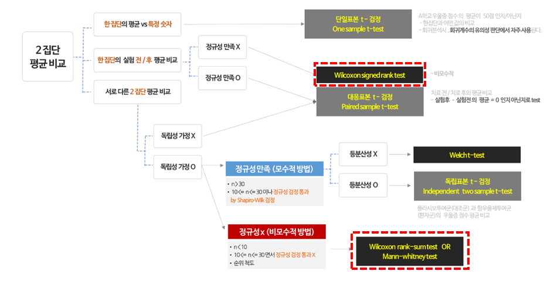

```python
import numpy as np
import pandas as pd
import matplotlib.pyplot as plt

# 정규성 검정
from scipy.stats import shapiro, anderson

# 비모수 검정
from scipy.stats import mannwhitneyu, ranksums, wilcoxon

# 등분산 검정
from scipy.stats import bartlett, fligner, levene

# 단일표본 t-검정
from scipy.stats import ttest_1samp

# 독립표본 t-검정
from scipy.stats import ttest_ind

# 대응표본 t-검정
from scipy.stats import ttest_rel

# 카이제곱 검정
from scipy.stats import chisquare, chi2_contingency, fisher_exact
```

## 정규성 검정

- 12명의 수험생이 빅데이터 분석기사 시험에서 받은 점수이다. Shapiro-Wilk 검정을 사용하여 데이터가 정규 분포를 따르는지 검증하시오 > 귀무 가설($H_0$) : 데이터는 정규 분포를 따른다.

> 대립 가설($H_1$) : 데이터는 정규 분포를 따르지 않는다.
- Shapiro-Wilk 검정 통계량, p-value, 검증결과를 출력하시오.

```python
data = [75, 83, 81, 92, 68, 77, 78, 80, 85, 95, 79, 89]

statistic, pvalue = shapiro(data)

alpha = 0.05
if pvalue < alpha :
    print(f'p-value : {pvalue : .3f}이므로 유의수준 5% 하에서 귀무가설을 기각한다.')
    print('즉, 데이터는 정규분포를 따르지 않는다.')
else :
    print(f'p-value : {pvalue : .3f}이므로 유의수준 5% 하에서 귀무가설을 채택한다.')
    print('즉, 데이터는 정규분포를 따른다.')
```

```
p-value :  0.968이므로 유의수준 5% 하에서 귀무가설을 채택한다.
즉, 데이터는 정규분포를 따른다.
```

## 단일표본 t-검정

- 다음은 22명의 학생들이 국어시험에서 받은 점수이다. 학생들의 평균이 75보다 크다고 할 수 있는가?

> 귀무가설($H_0$) : 모평균은 mu와 같다. (μ = mu), 학생들의 평균은 75이다.

> 대립가설($H_1$) : 모평균은 mu보다 크다. (μ > mu), 학생들의 평균은 75보다 크다.
- 가정 :
  - 모집단은 정규분포를 따른다.
  - 표본의 크기가 충분히 크다.
- 검정통계량, p-value, 검정결과를 출력하시오

```python
scores = [75, 80, 68, 72, 77, 82, 81, 79, 70, 74, 76, 78, 81, 73, 81, 78, 75, 72, 74, 79, 78, 79]
mu = 75

statistic, pvalue = ttest_1samp(scores, mu, alternative = 'greater')

alpha = 0.05
if pvalue < alpha :
    print(f'검정통계량 : {statistic :.3f} / p-value : {pvalue :.3f}이므로 유의수준 5% 하에서 귀무가설을 기각한다.')
    print('즉, 학생들의 평균은 75보다 크다.')
else :
    print(f'검정통계량 : {statistic :.3f} / p-value : {pvalue :.3f}이므로 유의수준 5% 하에서 귀무가설을 채택한다.')
    print('즉, 학생들의 평균은 75보다 크다고 할 수 없다.')
```

```
검정통계량 : 1.766 / p-value : 0.046이므로 유의수준 5% 하에서 귀무가설을 기각한다.
즉, 학생들의 평균은 75보다 크다.
```

## 대응(쌍체)표본 t-검정

- 주어진 데이터는 고혈압 환자 치료 전후의 혈압이다. 해당 치료가 효과가 있는지 대응(쌍체)표본 t-검정을 진행하시오.

> 귀무가설($H_0$) : μ $\geq$ 0

> 대립가설($H_1$) : μ < 0

> μ = (치료 후 혈압 - 치료 전 혈압)의 평균

> 유의수준: 0.05
- 문제
  1. μ의 표본평균은? (소수 둘째자리까지 반올림)
  2. 검정통계량 값은? (소수 둘째자리까지 반올림)
  3. p-값은? (소수 넷째자리까지 반올림)
  4. 가설검정의 결과는? (유의수준 5%)

```python
pressure = pd.read_csv('https://raw.githubusercontent.com/Opensourcefordatascience/Data-sets/master/blood_pressure.csv')

pressure['diff'] = pressure['bp_after'] - pressure['bp_before']
avg = (sum(pressure['diff']) / len(pressure['diff']))
print(f'문제 1 : {np.round(avg, 2)}')

# 정규성 검정
print(f'치료 후 - 치료 전 혈압의 정규성 검정 : {shapiro(pressure["diff"])}')

# 정규성 가정 후 대응표본 t-검정
statistic, pvalue = ttest_rel(pressure['bp_after'], pressure['bp_before'], alternative = 'less')

print(f'문제 2 : {np.round(statistic, 2)}')
print(f'문제 3 : {np.round(pvalue, 4)}')

alpha = 0.05
if pvalue < alpha :
    result = '기각'
    # print(f'가설검정 결과 유의수준 5% 하에서 귀무가설을 {result}한다. 즉, 치료의 효과가 있다.')
else :
    result = '채택'
    # print(f'가설검정 결과 유의수준 5% 하에서 귀무가설을 {result}한다. 즉, 치료의 효과가 없다.')

print(f'문제 4 : {result}')
```

[output not shown]

## 독립표본 t-검정

- 어떤 특정 약물을 복용한 사람들의 평균 체온이 복용하지 않은 사람들의 평균 체온과 유의미하게 다른지 검정해보려고 합니다.
- 가정 :
  - 약물을 복용한 그룹과 복용하지 않은 그룹의 체온 데이터가 각각 주어져 있다고 가정합니다.
  - 각 그룹의 체온은 정규분포를 따른다고 가정합니다.
- 가설 설정 :
  - $H_0$ : 약물을 복용한 그룹과 복용하지 않은 그룹의 평균 체온은 유의미한 차이가 없다.
  - $H_1$ : 약물을 복용한 그룹과 복용하지 않은 그룹의 평균 체온은 유의미한 차이가 있다.
- 검정통계량, p-value, 검정결과를 출력하시오.

```python
group1 = [36.8, 36.7, 37.1, 36.9, 37.2, 36.8, 36.9, 37.1, 36.7, 37.1]
group2 = [36.5, 36.6, 36.3, 36.6, 36.9, 36.7, 36.7, 36.8, 36.5, 36.7]

statistic, pvalue = ttest_ind(group1, group2)

alpha = 0.05
if pvalue < alpha :
    print(f'검정통계량 : {statistic :.3f} / p-value : {pvalue :.3f}이므로 유의수준 5% 하에서 귀무가설을 기각한다.')
    print('즉, 약물을 복용한 그룹과 복용하지 않은 그룹의 평균 체온은 유의미한 차이가 있다.')
else :
    print(f'검정통계량 : {statistic :.3f} / p-value : {pvalue :.3f}이므로 유의수준 5% 하에서 귀무가설을 채택한다.')
    print('즉, 약물을 복용한 그룹과 복용하지 않은 그룹의 평균 체온은 유의미한 차이가 없다.')
```

```
검정통계량 : 3.796 / p-value : 0.001이므로 유의수준 5% 하에서 귀무가설을 기각한다.
즉, 약물을 복용한 그룹과 복용하지 않은 그룹의 평균 체온은 유의미한 차이가 있다.
```

## 회귀모형

- `iris` 데이터셋에서 Sepal Length와 Sepal Width의 상관계수 계산하고 소수 둘째자리까지 출력하시오.

```python
from sklearn.datasets import load_iris
iris = load_iris()
df = pd.DataFrame(iris.data, columns = iris.feature_names)

corr_df = df.corr()
corr = corr_df.loc['sepal length (cm)', 'sepal width (cm)']
print(f'Sepal Length와 Sepal Width의 상관계수 : {corr : .2f}')
```

```
Sepal Length와 Sepal Width의 상관계수 : -0.12
```